# Explore_bikeshare_data

### Explore Bike Share Data

For this project, your goal is to ask and answer three questions about the available bikeshare data from Washington, Chicago, and New York. This notebook can be submitted directly through the workspace when you are confident in your results.

You will be graded against the project [Rubric](https://review.udacity.com/#!/rubrics/2508/view) by a mentor after you have submitted. To get you started, you can use the template below, but feel free to be creative in your solutions!

```r
install.packages("summarytools");
```

```r
library(ggplot2);
library(summarytools);
library(dplyr);
```

```r
ny = read.csv('new_york_city.csv')
wash = read.csv('washington.csv')
chi = read.csv('chicago.csv')
```

```r
head(ny)
```

| X | Start.Time | End.Time | Trip.Duration | Start.Station | End.Station | User.Type | Gender | Birth.Year |
| --- | --- | --- | --- | --- | --- | --- | --- | --- |
| 5688089 | 2017-06-11 14:55:05 | 2017-06-11 15:08:21 | 795 | Suffolk St & Stanton St | W Broadway & Spring St | Subscriber | Male | 1998 |
| 4096714 | 2017-05-11 15:30:11 | 2017-05-11 15:41:43 | 692 | Lexington Ave & E 63 St | 1 Ave & E 78 St | Subscriber | Male | 1981 |
| 2173887 | 2017-03-29 13:26:26 | 2017-03-29 13:48:31 | 1325 | 1 Pl & Clinton St | Henry St & Degraw St | Subscriber | Male | 1987 |
| 3945638 | 2017-05-08 19:47:18 | 2017-05-08 19:59:01 | 703 | Barrow St & Hudson St | W 20 St & 8 Ave | Subscriber | Female | 1986 |
| 6208972 | 2017-06-21 07:49:16 | 2017-06-21 07:54:46 | 329 | 1 Ave & E 44 St | E 53 St & 3 Ave | Subscriber | Male | 1992 |
| 1285652 | 2017-02-22 18:55:24 | 2017-02-22 19:12:03 | 998 | State St & Smith St | Bond St & Fulton St | Subscriber | Male | 1986 |

```r
head(wash)
```

| X | Start.Time | End.Time | Trip.Duration | Start.Station | End.Station | User.Type |
| --- | --- | --- | --- | --- | --- | --- |
| 1621326 | 2017-06-21 08:36:34 | 2017-06-21 08:44:43 | 489.066 | 14th & Belmont St NW | 15th & K St NW | Subscriber |
| 482740 | 2017-03-11 10:40:00 | 2017-03-11 10:46:00 | 402.549 | Yuma St & Tenley Circle NW | Connecticut Ave & Yuma St NW | Subscriber |
| 1330037 | 2017-05-30 01:02:59 | 2017-05-30 01:13:37 | 637.251 | 17th St & Massachusetts Ave NW | 5th & K St NW | Subscriber |
| 665458 | 2017-04-02 07:48:35 | 2017-04-02 08:19:03 | 1827.341 | Constitution Ave & 2nd St NW/DOL | M St & Pennsylvania Ave NW | Customer |
| 1481135 | 2017-06-10 08:36:28 | 2017-06-10 09:02:17 | 1549.427 | Henry Bacon Dr & Lincoln Memorial Circle NW | Maine Ave & 7th St SW | Subscriber |
| 1148202 | 2017-05-14 07:18:18 | 2017-05-14 07:24:56 | 398.000 | 1st & K St SE | Eastern Market Metro / Pennsylvania Ave & 7th St SE | Subscriber |

```r
head(chi)
```

| X | Start.Time | End.Time | Trip.Duration | Start.Station | End.Station | User.Type | Gender | Birth.Year |
| --- | --- | --- | --- | --- | --- | --- | --- | --- |
| 1423854 | 2017-06-23 15:09:32 | 2017-06-23 15:14:53 | 321 | Wood St & Hubbard St | Damen Ave & Chicago Ave | Subscriber | Male | 1992 |
| 955915 | 2017-05-25 18:19:03 | 2017-05-25 18:45:53 | 1610 | Theater on the Lake | Sheffield Ave & Waveland Ave | Subscriber | Female | 1992 |
| 9031 | 2017-01-04 08:27:49 | 2017-01-04 08:34:45 | 416 | May St & Taylor St | Wood St & Taylor St | Subscriber | Male | 1981 |
| 304487 | 2017-03-06 13:49:38 | 2017-03-06 13:55:28 | 350 | Christiana Ave & Lawrence Ave | St. Louis Ave & Balmoral Ave | Subscriber | Male | 1986 |
| 45207 | 2017-01-17 14:53:07 | 2017-01-17 15:02:01 | 534 | Clark St & Randolph St | Desplaines St & Jackson Blvd | Subscriber | Male | 1975 |
| 1473887 | 2017-06-26 09:01:20 | 2017-06-26 09:11:06 | 586 | Clinton St & Washington Blvd | Canal St & Taylor St | Subscriber | Male | 1990 |

### Question 1

**What is the most common month for travel across all cities?**

```r
# Extract months from each dataframe into vectors and concatenate them into allmonths
nymonths <- with(ny, months(as.Date(Start.Time)))
washmonths <- with(wash, months(as.Date(Start.Time)))
chimonths <- with(chi, months(as.Date(Start.Time)))
allmonths <- data.frame(Months=c(nymonths, washmonths, chimonths))
head(allmonths)
```

| Months |
| --- |
| June |
| May |
| March |
| May |
| June |
| February |

```r
# Check that the length of allmonths is the sum of the numbers of rows in each dataframe
stopifnot(nrow(ny)+nrow(wash)+nrow(chi)==nrow(allmonths))
nrow(allmonths)
```

152451

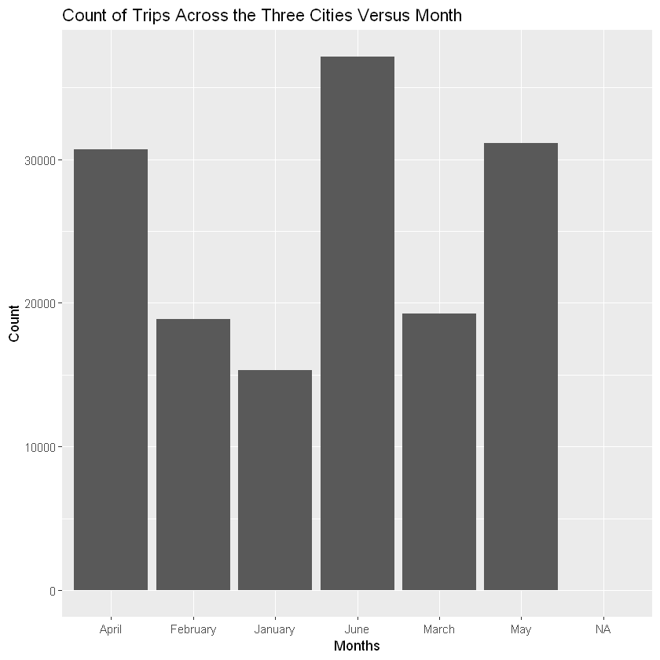

```r
# Make a histogram of months
ggplot(aes(x = Months), data = allmonths)  + geom_bar() + labs(y = "Count",
    title = "Counts of Trips Across the Three Cities Versus Month")
```

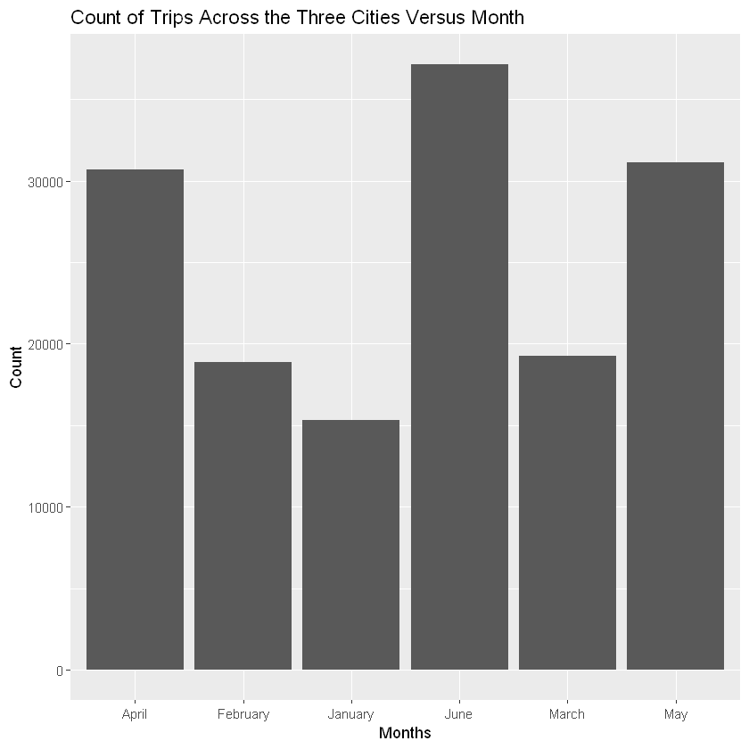

```r
# In the histogram above, there is an NA bar that is practically zero. (There is one NA entry as the summary below shows.)
# We will remove the NA bar here.
ggplot(aes(x = Months), data = na.omit(allmonths))  + geom_bar() + labs(y = "Count",
    title = "Counts of Trips Across the Three Cities Versus Month")
```

```r
summary(allmonths)
```

```
      Months
 April   :30709
 February:18857
 January :15341
 June    :37151
 March   :19235
 May     :31157
 NA's    :    1
```

```r
freqs=freq(allmonths, order="freq")[,c("Freq","% Valid")]
freqs
```

|  | Freq | % Valid |
| --- | --- | --- |
| June | 37151 | 24.36930 |
| May | 31157 | 20.43752 |
| April | 30709 | 20.14365 |
| March | 19235 | 12.61725 |
| February | 18857 | 12.36930 |
| January | 15341 | 10.06297 |
| <NA> | 1 | NA |
| Total | 152451 | 100.00000 |

```r
summary(freqs)
```

```
      Freq           % Valid
 Min.   :     1   Min.   : 10.06
 1st Qu.: 17978   1st Qu.: 12.49
 Median : 24972   Median : 20.14
 Mean   : 38113   Mean   : 28.57
 3rd Qu.: 32656   3rd Qu.: 22.40
 Max.   :152451   Max.   :100.00
                  NA's   :1
```

### Question 2

**What is the most common end station in each city?**

```r
# Add a column to each dataframe with the city name
ny$City = "New York"
wash$City = "Washington"
chi$City = "Chicago"
```

```r
# Make a dataframe with the top 3 commonly used end stations from each city
endStationsTopTens <- data.frame(End.Station=character(),City=character(),stringsAsFactors=FALSE)

for (df in list(ny, wash, chi)) {
    endStations <- data.frame(End.Station=df$End.Station, City=df$City)
    endStationsFreqs <- data.frame(table(endStations$End.Station))
    colnames(endStationsFreqs) <- c('End.Station', 'Frequency')
    head(endStationsFreqs)
    endStationsFreqs <- endStationsFreqs[order(endStationsFreqs$Frequency, decreasing=TRUE),][1:3,]
    endStationsFreqs$City <- df$City[1]
    endStationsTopTens <- rbind(endStationsTopTens, endStationsFreqs)
}

row.names(endStationsTopTens) <- NULL
endStationsTopTens$order = c(1:nrow(endStationsTopTens))
head(endStationsTopTens,30)
```

| End.Station | Frequency | City | order |
| --- | --- | --- | --- |
| Pershing Square North | 556 | New York | 1 |
| E 17 St & Broadway | 445 | New York | 2 |
| Broadway & E 22 St | 427 | New York | 3 |
| Columbus Circle / Union Station | 1767 | Washington | 4 |
| Jefferson Dr & 14th St SW | 1603 | Washington | 5 |
| Lincoln Memorial | 1514 | Washington | 6 |
| Streeter Dr & Grand Ave | 233 | Chicago | 7 |
| Clinton St & Madison St | 145 | Chicago | 8 |
| Theater on the Lake | 131 | Chicago | 9 |

```r
# Check that we have 9 top stations in total, 3 for each city
stopifnot(nrow(endStationsTopTens)==9)
nrow(endStationsTopTens)
```

9

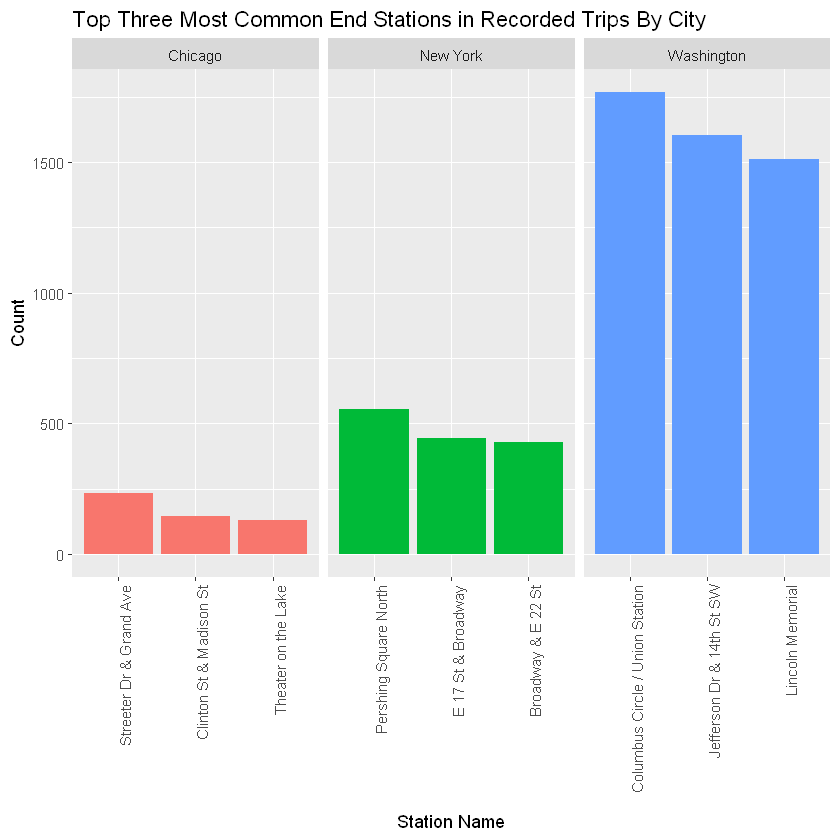

```r
# Make a faceted of top 5 most commonly used stations from each city.
ggplot(aes(x = reorder(End.Station, order), y=Frequency, fill = as.factor(City)), data = endStationsTopTens) +
       geom_bar(stat="identity") +
       facet_grid(~City, scales = "free", space = "free") + theme(axis.text.x = element_text(angle = 90, hjust = 1)) +
       labs(x = "Station Name", fill = "City", y = "Count", title = "Top Three Most Common End Stations in Recorded Trips by City") +
       theme(legend.position = "none")
```

```r
# Top 5 commonly used station in New York
freq(ny$End.Station, order="freq")[1:5,]
```

|  | Freq | % Valid | % Valid Cum. | % Total | % Total Cum. |
| --- | --- | --- | --- | --- | --- |
| Pershing Square North | 556 | 1.0151543 | 1.015154 | 1.0151543 | 1.015154 |
| E 17 St & Broadway | 445 | 0.8124886 | 1.827643 | 0.8124886 | 1.827643 |
| Broadway & E 22 St | 427 | 0.7796239 | 2.607267 | 0.7796239 | 2.607267 |
| W 21 St & 6 Ave | 365 | 0.6664232 | 3.273690 | 0.6664232 | 3.273690 |
| W 20 St & 11 Ave | 344 | 0.6280811 | 3.901771 | 0.6280811 | 3.901771 |

```r
# Top 5 commonly used station in Washinton
freq(wash$End.Station, order="freq")[1:5,]
```

|  | Freq | % Valid | % Valid Cum. | % Total | % Total Cum. |
| --- | --- | --- | --- | --- | --- |
| Columbus Circle / Union Station | 1767 | 1.984256 | 1.984256 | 1.984256 | 1.984256 |
| Jefferson Dr & 14th St SW | 1603 | 1.800092 | 3.784348 | 1.800092 | 3.784348 |
| Lincoln Memorial | 1514 | 1.700149 | 5.484498 | 1.700149 | 5.484498 |
| Massachusetts Ave & Dupont Circle NW | 1344 | 1.509248 | 6.993745 | 1.509248 | 6.993745 |
| Smithsonian-National Mall / Jefferson Dr & 12th St SW | 1103 | 1.238616 | 8.232361 | 1.238616 | 8.232361 |

```r
# Top 5 commonly used station in Chicago
freq(chi$End.Station, order="freq")[1:5,]
```

|  | Freq | % Valid | % Valid Cum. | % Total | % Total Cum. |
| --- | --- | --- | --- | --- | --- |
| Streeter Dr & Grand Ave | 233 | 2.699884 | 2.699884 | 2.699884 | 2.699884 |
| Clinton St & Madison St | 145 | 1.680185 | 4.380070 | 1.680185 | 4.380070 |
| Theater on the Lake | 131 | 1.517961 | 5.898030 | 1.517961 | 5.898030 |
| Lake Shore Dr & Monroe St | 115 | 1.332561 | 7.230591 | 1.332561 | 7.230591 |
| Clinton St & Washington Blvd | 109 | 1.263036 | 8.493627 | 1.263036 | 8.493627 |

```r
endStationsTopTens %>%
  group_by(City) %>%
  summarise(Sum.Frequency=sum(Frequency),
            Mean.Frequency=mean(Frequency),
            Median.Frequency=median(Frequency),
            First.Quantile.Frequency=quantile(Frequency,0.25,na.rm=TRUE),
            Fourth.Quantile.Frequency=quantile(Frequency,0.75,na.rm=TRUE))
```

| City | Sum.Frequency | Mean.Frequency | Median.Frequency | First.Quantile.Frequency | Fourth.Quantile.Frequency |
| --- | --- | --- | --- | --- | --- |
| Chicago | 509 | 169.6667 | 145 | 138.0 | 189.0 |
| New York | 1428 | 476.0000 | 445 | 436.0 | 500.5 |
| Washington | 4884 | 1628.0000 | 1603 | 1558.5 | 1685.0 |

**We note that the median number of recorded trips for end station in Chicago, Washington, and New York were 145, 1603, and 445, respectively.**

### Question 3

**How do the trip durations compare between the New York and Chicago, as well as by genders?**

```r
# Make a dataframe with all trip durations from each city
tripDurationsTwoCities <- data.frame(Trip.Duration=numeric(),City=character(),Gender=character(),stringsAsFactors=FALSE)

for (df in list(ny, chi)) {
    tripDurationsTwoCities <- rbind(tripDurationsTwoCities, data.frame(Trip.Duration=df$Trip.Duration, City=df$City, Gender=df$Gender))
}

row.names(tripDurationsTwoCities) <- NULL
tripDurationsTwoCities$order = c(1:nrow(tripDurationsTwoCities))
head(tripDurationsTwoCities)
```

| Trip.Duration | City | Gender | order |
| --- | --- | --- | --- |
| 795 | New York | Male | 1 |
| 692 | New York | Male | 2 |
| 1325 | New York | Male | 3 |
| 703 | New York | Female | 4 |
| 329 | New York | Male | 5 |
| 998 | New York | Male | 6 |

```r
summary(tripDurationsTwoCities)
```

```
 Trip.Duration             City          Gender          order
 Min.   :     60.0   New York:54770         : 7158   Min.   :    1
 1st Qu.:    371.0   Chicago : 8630   Female:13882   1st Qu.:15851
 Median :    617.0                    Male  :42360   Median :31701
 Mean   :    908.2                                   Mean   :31701
 3rd Qu.:   1060.0                                   3rd Qu.:47550
 Max.   :1088634.0                                   Max.   :63400
 NA's   :1
```

```r
levels(tripDurationsTwoCities$Gender) <- c(levels(tripDurationsTwoCities$Gender), "Unknown")
tripDurationsTwoCities$Gender[(tripDurationsTwoCities$Gender!="Male")&(tripDurationsTwoCities$Gender!="Female")] <- "Unknown"
```

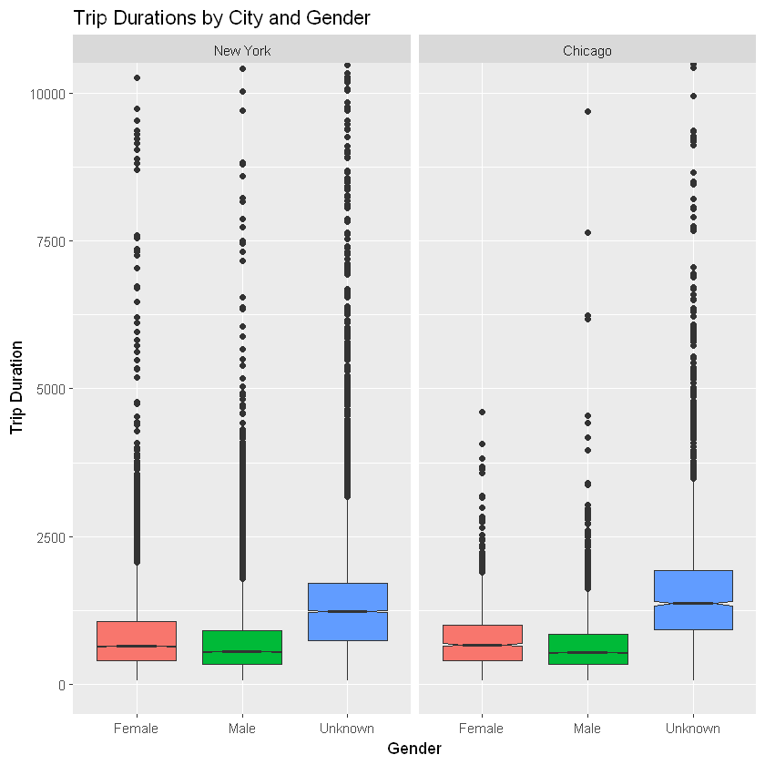

```r
# Make a faceted of top 5 most commonly used stations from each city.
ggplot(tripDurationsTwoCities, aes(x = Gender, y = Trip.Duration, group=Gender, fill = as.factor(Gender))) +
       geom_boxplot(notch=TRUE) +
       facet_grid(.~City) +
       labs(y = "Trip Duration", title = "Trip Durations by City and Gender") +
       theme(legend.position = "none") +
       coord_cartesian(ylim = c(0, 10000))
```

```r
summary(tripDurationsTwoCities)
```

```
 Trip.Duration             City           Gender          order
 Min.   :     60.0   New York:54770          :    0   Min.   :    1
 1st Qu.:    371.0   Chicago : 8630   Female :13882   1st Qu.:15851
 Median :    617.0                    Male   :42360   Median :31701
 Mean   :    908.2                    Unknown: 7158   Mean   :31701
 3rd Qu.:   1060.0                                    3rd Qu.:47550
 Max.   :1088634.0                                    Max.   :63400
 NA's   :1
```

```r
tripDurationsTwoCities %>%
  group_by(City, Gender) %>%
  summarise(Sum.Trip.Duration=sum(Trip.Duration,na.rm=TRUE),
            Mean.Trip.Duration=mean(Trip.Duration,na.rm=TRUE),
            Median.Trip.Duration=median(Trip.Duration,na.rm=TRUE),
            First.Quantile.Trip.Duration=quantile(Trip.Duration,0.25,na.rm=TRUE),
            Fourth.Quantile.Trip.Duration=quantile(Trip.Duration,0.75,na.rm=TRUE))
```

| City | Gender | Sum.Trip.Duration | Mean.Trip.Duration | Median.Trip.Duration | First.Quantile.Trip.Duration | Fourth.Quantile.Trip.Duration |
| --- | --- | --- | --- | --- | --- | --- |
| New York | Female | 10651022 | 875.9785 | 644 | 400.00 | 1068.0 |
| New York | Male | 28604515 | 768.9179 | 551 | 340.00 | 918.0 |
| New York | Unknown | 10234536 | 1892.1309 | 1232 | 738.00 | 1709.0 |
| Chicago | Female | 1333622 | 774.0116 | 668 | 406.00 | 1004.5 |
| Chicago | Male | 3381350 | 655.4274 | 536 | 338.00 | 847.5 |
| Chicago | Unknown | 3372829 | 1929.5360 | 1370 | 918.75 | 1934.0 |

```r
tripDurationsTwoCities %>%
  group_by(City) %>%
  summarise(Sum.Trip.Duration=sum(Trip.Duration,na.rm=TRUE),
            Mean.Trip.Duration=mean(Trip.Duration,na.rm=TRUE),
            Median.Trip.Duration=median(Trip.Duration,na.rm=TRUE),
            First.Quantile.Trip.Duration=quantile(Trip.Duration,0.25,na.rm=TRUE),
            Fourth.Quantile.Trip.Duration=quantile(Trip.Duration,0.75,na.rm=TRUE))
```

| City | Sum.Trip.Duration | Mean.Trip.Duration | Median.Trip.Duration | First.Quantile.Trip.Duration | Fourth.Quantile.Trip.Duration |
| --- | --- | --- | --- | --- | --- |
| New York | 49490073 | 903.6147 | 610 | 368.00 | 1051 |
| Chicago | 8087801 | 937.1728 | 670 | 394.25 | 1119 |

**In both New York and Chicago, the median trip duration made by females was slightly larger than the number of trips made by males. In particular, in New York, the median trip durations by males and females were 551 and 644 respectively, and in Chicago 536 and 668 respectively.**

**There is also a category of trips with the gender unknown, which has higher medians than those of males and females: 1232 in New York and 1370 in Chicago.**

**The median trip duration in New York was 610, which is lower than 670 in Chicago.**

## Finishing Up

> Congratulations! You have reached the end of the Explore Bikeshare Data Project. You should be very proud of all you have accomplished!

> **Tip**: Once you are satisfied with your work here, check over your report to make sure that it is satisfies all the areas of the [rubric](https://review.udacity.com/#!/rubrics/2508/view).

## Directions to Submit

> Before you submit your project, you need to create a .html or .pdf version of this notebook in the workspace here. To do that, run the code cell below. If it worked correctly, you should get a return code of 0, and you should see the generated .html file in the workspace directory (click on the orange Jupyter icon in the upper left).

> Alternatively, you can download this report as .html via the **File** > **Download as** submenu, and then manually upload it into the workspace directory by clicking on the orange Jupyter icon in the upper left, then using the Upload button.

> Once you've done this, you can submit your project by clicking on the "Submit Project" button in the lower right here. This will create and submit a zip file with this .ipynb doc and the .html or .pdf version you created. Congratulations!

```r
system('python -m nbconvert Explore_bikeshare_data.ipynb')
```